# Analysing candidates to the Chamber of Deputies throughout the elections

Bogdan Romenskii

28.12.2022

### Introduction

In this report data about candidates to the Chamber of Deputies of the Czech Republic will be analysed. The said data was gathered during the elections in the years 2006 - 2021. The source is [Czech Statistical Office](https://www.volby.cz/opendata/opendata.htm). The following analysis will answer these questions:

- What is candidates’ age distribution?
- What is men to women ratio?
- Which ideology prevails among the candidates?
- What fields of work are the most frequent?
- Does university education have any influence on candidates’ ideology?

In the last part a binary classification algorithm will be trained to define whether the candidate will be elected based on the given features.

```r
library(plyr) # mapvalues function
library(tidyverse) # data manipulation library
library(jsonlite) # for JSON files manipulation
library(glue) # for python f-string analogue
```

### Data uploading and preprocessing

In the following cells auxiliary files and functions will be uploaded and defined for further use

```r
# list of the regions of the Czech Republic
kraj_list <- c("Hlavní město Praha", "Středočeský kraj", "Jihočeský kraj", "Plzeňský kraj", "Karlovarský kraj",
               "Ústecký kraj", "Liberecký kraj", "Královéhradecký kraj", "Pardubický kraj", "Kraj Vysočina",
               "Jihomoravský kraj", "Olomoucký kraj", "Zlínský kraj", "Moravskoslezský kraj")

# data about political parties and their ideology (left-wing - right-wing)
strany <- read_csv2("legislative-elections/strany.csv",
                    locale = locale(encoding = "UTF-8"))

# key words for candidates' field definition
obor_json <- fromJSON("dict_occupations.json")
```

```r
# Check to what field does candidate's profession belongs to (such as finance, law, medicine etc.) with the help of keywords
obor_fun <- function(val, dict){
  for(i in seq_along(dict)){
    for(j in seq_along(dict[[i]]$var)){
      if(grepl(dict[[i]]$var[j], tolower(val), fixed = TRUE)){
        return(dict[[i]]$name)
      }
    }
  }
  return("jine")
}
```

```r
# Clean and prepare a dataframe containing data from different elections for further visualisation and modelling purposes.
clean_data <- function(df){
  df1 <- df %>%
    # creates a new column with name and surname as one
    mutate(name = paste(JMENO, PRIJMENI, sep = " "),
           # checks whether the candidate has any titles, if so - university degree is set to 1
           degree = if_else(
             !is.na(TITULPRED) | !is.na(TITULZA), "yes", "no"
           ),
           # maps regions' names
           region = mapvalues(VOLKRAJ, 1:14, kraj_list),
           # transforms mandate to standard form
           mandate = if_else(
             MANDAT == "A" | MANDAT == "1", "yes", "no"
           ),
           # obor_fun function is applied on a POVOLANI column, unlists is used twice after that
           field = unlist(
             unlist(
               lapply(df$POVOLANI, function(x) lapply(x, obor_fun, obor_json)),
               recursive = FALSE),
             recursive = FALSE)) %>%
    # creates gender column based on surname ending
    mutate(sex = if_else(
      substr(name, nchar(name), nchar(name)) == "á", "F", "M"
    )) %>%
    # joins another table to map candidates' ideology based on their party
    left_join(strany %>%
                select(VSTRANA, Ideologie),
              by = c("NSTRANA" = "VSTRANA")) %>%
    # selects only relevant columns
    select(name, VEK, degree, field, sex, region, Ideologie, mandate) %>%
    # renames some of the columns to match the standard format
    rename("age" = "VEK",
           "ideology" = "Ideologie") %>%
    # changes data types to factors in the according columns
    mutate(degree = factor(degree),
           field = factor(field),
           sex = factor(sex),
           region = factor(region),
           ideology = factor(ideology),
           mandate = factor(mandate, levels = c("yes", "no")))

  return(df1)
}
```

The data after cleaning consists of 9 columns:

- **name**: candidate’s name and surname
- **age**
- **degree**: whether the candidate has university degree
- **field**: field of work
- **sex**
- **region**
- **ideology**: ideology of the party that proposed the candidate
- **mandate**: whether the candidate received mandate eventually
- **year**: the year the elections were held

The data from all available elections will be combined to one dataframe for further visualisation and modelling purposes.

```r
snem_list <- list()
years <- c("2006", "2010", "2013", "2017", "2021")

# the following loop iterates through the list, uploads the csv file, cleans it and assigns it back to list
for(i in seq_along(years)){
  year <- years[i]
  snem_list[[i]] <- clean_data(
    read_csv2(glue("legislative-elections/snem_{year}.csv"),
                              locale = locale(encoding = "UTF-8"))
  )
  snem_list[[i]]$year <- year
}

# combining data throughout the years to one dataframe
snem_long <- rbind.fill(snem_list) %>%
  mutate(year = factor(year))

head(snem_long, 10)
```

|  | name | age | degree | field | sex | region | ideology | mandate | year |
| --- | --- | --- | --- | --- | --- | --- | --- | --- | --- |
| 1 | František Zwyrtek | 45 | no | management | M | Moravskoslezský kraj | Střed | no | 2006 |
| 2 | Vladimír Mach | 63 | yes | státní zaměstnanec | M | Moravskoslezský kraj | Střed | no | 2006 |
| 3 | Zdeněk Stolař | 51 | yes | zdravotnictví | M | Moravskoslezský kraj | Střed | no | 2006 |
| 4 | Alena Hasáková | 51 | yes | státní zaměstnanec | F | Moravskoslezský kraj | Střed | no | 2006 |
| 5 | Alois Čtvrtníček | 60 | yes | podnikání | M | Moravskoslezský kraj | Střed | no | 2006 |
| 6 | Hana Doležalová | 33 | yes | státní zaměstnanec | F | Moravskoslezský kraj | Střed | no | 2006 |
| 7 | Václav Kafka | 63 | yes | věda | M | Moravskoslezský kraj | Střed | no | 2006 |
| 8 | Libuše Koppová | 59 | no | zdravotnictví | F | Moravskoslezský kraj | Střed | no | 2006 |
| 9 | Alexander Nedbálek | 51 | yes | zdravotnictví | M | Moravskoslezský kraj | Střed | no | 2006 |
| 10 | Jan Fismol | 59 | yes | politika | M | Moravskoslezský kraj | Střed | no | 2006 |

As can be seen below, the dataframe consists mostly of categorical data with age being the only numeric variable

```r
glimpse(snem_long)
```

```
## Rows: 28,778
## Columns: 9
## $ name     <chr> "František Zwyrtek", "Vladimír Mach", "Zdeněk Stolař", "Alena…
## $ age      <dbl> 45, 63, 51, 51, 60, 33, 63, 59, 51, 59, 61, 38, 60, 28, 51, 3…
## $ degree   <fct> no, yes, yes, yes, yes, yes, yes, no, yes, yes, no, yes, yes,…
## $ field    <fct> management, státní zaměstnanec, zdravotnictví, státní zaměstn…
## $ sex      <fct> M, M, M, F, M, F, M, F, M, M, M, F, M, F, M, M, F, M, M, M, M…
## $ region   <fct> Moravskoslezský kraj, Moravskoslezský kraj, Moravskoslezský k…
## $ ideology <fct> Střed, Střed, Střed, Střed, Střed, Střed, Střed, Střed, Střed…
## $ mandate  <fct> no, no, no, no, no, no, no, no, no, no, no, no, no, no, no, n…
## $ year     <fct> 2006, 2006, 2006, 2006, 2006, 2006, 2006, 2006, 2006, 2006, 2…
```

Missing values may be noticed in two columns: age and ideology. The latter may be due to candidates standing as independent. Although the former requires some investigation.

```r
colSums(is.na(snem_long))
```

```
##     name      age   degree    field      sex   region ideology  mandate
##        0       11        0        0        0        0      214        0
##     year
##        0
```

The missing age stands for missing candidates on initial elections paper. These entities can be deleted without information loss.

```r
snem_long %>%
        filter(is.na(age))
```

| name | age | degree | field | sex | region | ideology | mandate | year |
| --- | --- | --- | --- | --- | --- | --- | --- | --- |
| Registrační úřad ponechal pozici volnou Kandidát v registraci škrtnut | NA | no | jine | M | Zlínský kraj | NA | no | 2010 |
| Registrační úřad ponechal pozici volnou Kandidát v registraci škrtnut | NA | no | jine | M | Ústecký kraj | NA | no | 2010 |
| Registrační úřad ponechal pozici volnou Kandidát v registraci škrtnut | NA | no | jine | M | Ústecký kraj | NA | no | 2010 |
| Registrační úřad ponechal pozici volnou Kandidát v registraci škrtnut | NA | no | jine | M | Ústecký kraj | NA | no | 2010 |
| Registrační úřad ponechal pozici volnou Kandidát v registraci škrtnut | NA | no | jine | M | Ústecký kraj | NA | no | 2010 |
| Registrační úřad ponechal pozici volnou Kandidát v registraci škrtnut | NA | no | jine | M | Jihočeský kraj | NA | no | 2013 |
| Registrační úřad ponechal pozici volnou Kandidát v registraci škrtnut | NA | no | jine | M | Zlínský kraj | NA | no | 2017 |
| Registrační úřad ponechal pozici volnou Kandidát v registraci škrtnut | NA | no | jine | M | Ústecký kraj | NA | no | 2021 |
| Registrační úřad ponechal pozici volnou Kandidát v registraci škrtnut | NA | no | jine | M | Ústecký kraj | NA | no | 2021 |
| Registrační úřad ponechal pozici volnou Kandidát v registraci škrtnut | NA | no | jine | M | Kraj Vysočina | NA | no | 2021 |

[output cut: 1 more lines]

Randomly generated values will be imputed into missing ideologies to preserve the original ratios.

```r
snem_long <- snem_long %>%
        # deleting the dummy NA rows
        drop_na(age)

# imputing the array of 3 levels into NA values
snem_long[is.na(snem_long$ideology), "ideology"] <- gl(3, 1, 203, labels = levels(snem_long$ideology))

colSums(is.na(snem_long))
```

```
##     name      age   degree    field      sex   region ideology  mandate
##        0        0        0        0        0        0        0        0
##     year
##        0
```

Now when all missing data is taken care of, the exploratory analysis may be performed.

### Exploratory Data Analysis

#### Candidates’ age distribution

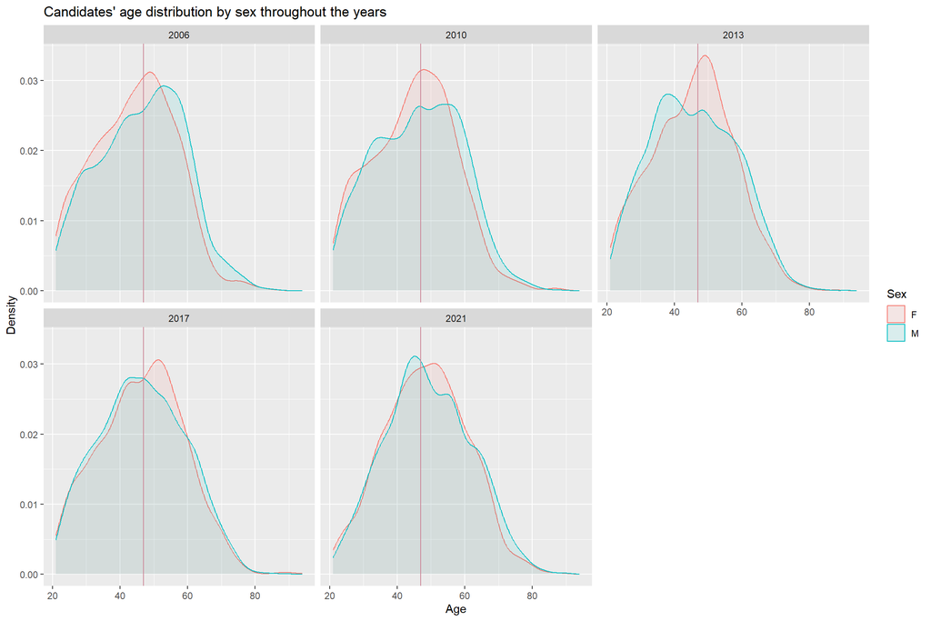

```r
ggplot(snem_long, aes(age)) +
        geom_density(aes(colour = sex, fill = sex), alpha = 0.1) +
        geom_vline(aes(xintercept = median(age)), colour = "#CC8899") +
        facet_wrap(vars(year)) +
        labs(title = "Candidates' age distribution by sex throughout the years",
             x = "Age",
             y = "Density",
             fill = "Sex",
             colour = "Sex")
```

#### Sex ratio

Male to female ratio seems to be consistent as well. Almost always it is 3:1, although in 2021 the share of female candidates has slightly increased.

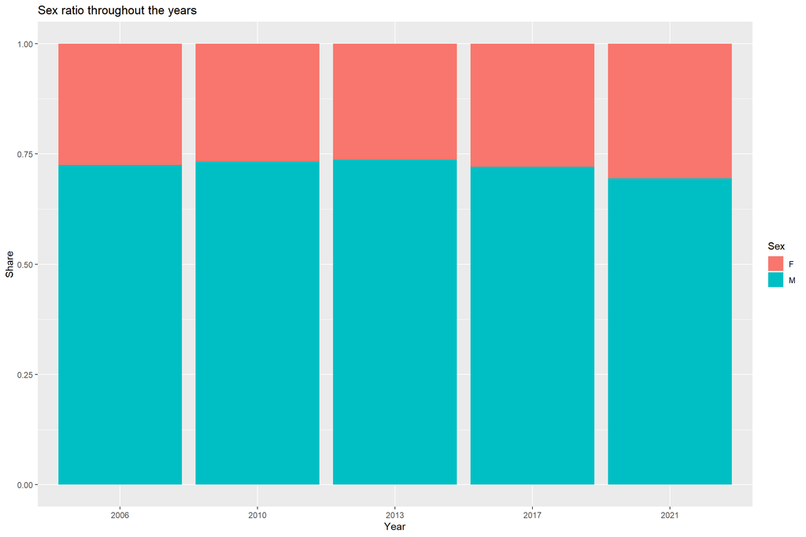

```r
ggplot(snem_long, aes(year)) +
        geom_bar(aes(fill = sex), position = "fill") +
        labs(title = "Sex ratio throughout the years",
             x = "Year",
             y = "Share",
             fill = "Sex")
```

#### Candidates’ ideologies count throughout the regions

The next two visualisations compare candidates’ ideologies in different regions throughout the years. As can be seen, right-wing ideology prevails among the candidates in all regions, albeit centrists are elected more often.

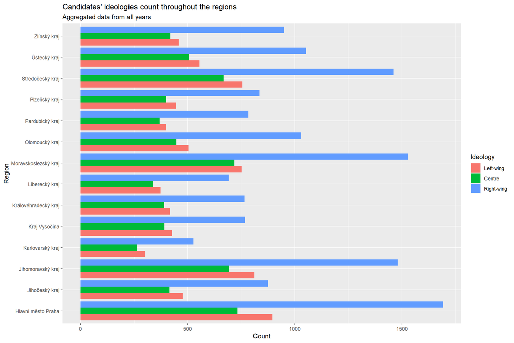

```r
snem_long %>%
  mutate(ideology = fct_relevel(ideology, "Levice", "Střed", "Pravice")) %>%
  ggplot(aes(region)) +
        geom_bar(aes(fill = ideology), position = "dodge") +
        scale_fill_discrete(name = "Ideology", labels = c("Left-wing", "Centre", "Right-wing")) +
        labs(title = "Candidates' ideologies count throughout the regions",
             subtitle = "Aggregated data from all years",
             x = "Region",
             y = "Count") +
        coord_flip()
```

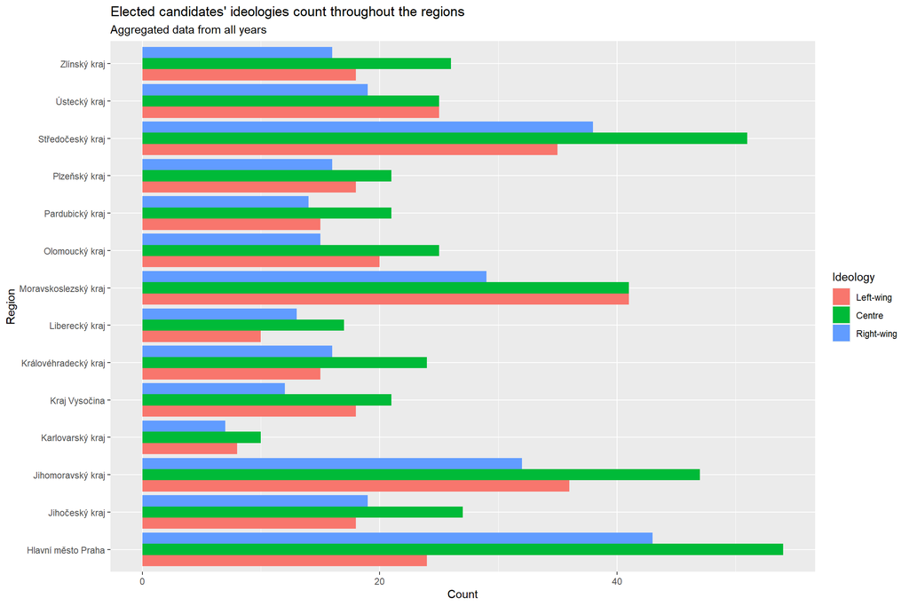

```r
snem_long %>%
  filter(mandate == "yes") %>%
  mutate(ideology = fct_relevel(ideology, "Levice", "Střed", "Pravice")) %>%
  ggplot(aes(region)) +
  geom_bar(aes(fill = ideology), position = "dodge") +
  scale_fill_discrete(name = "Ideology", labels = c("Left-wing", "Centre", "Right-wing")) +
  labs(title = "Elected candidates' ideologies count throughout the regions",
       subtitle = "Aggregated data from all years",
       x = "Region",
       y = "Count") +
  coord_flip()
```

#### The most frequent fields of work

This visualisation shows the most frequent fields of work. Private sector has the biggest representation, most candidates coming from this field have no university degree. The second most frequent group of candidates are those who are in politics already (e.g. mayors, governors), candidates coming from this field often possess university degree. The third field is businesspeople, university degrees are not prevalent in this group as well.

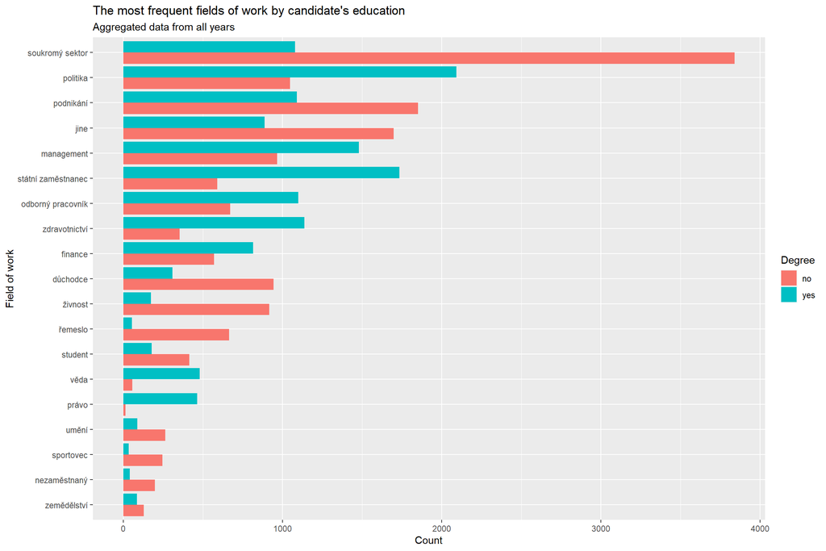

```r
snem_long %>%
  mutate(field = fct_reorder(field, degree, .fun = "length", .desc = FALSE)) %>%
  ggplot(aes(field)) +
    geom_bar(aes(fill = degree), position = "dodge") +
    labs(title = "The most frequent fields of work by candidate's education",
         subtitle = "Aggregated data from all years",
         x = "Field of work",
         y = "Count",
         fill = "Degree") +
    coord_flip()
```

#### Candidates’ ideologies ratio

The last plot shows the share of ideologies based on whether the candidates have university degree or not. Candidates with no university education tend to be more right-wing, whilst the share of other ideologies is smaller in comparison. The presence of diploma seems to make candidates pick other ideologies as well: almost equal shares may be noticed.

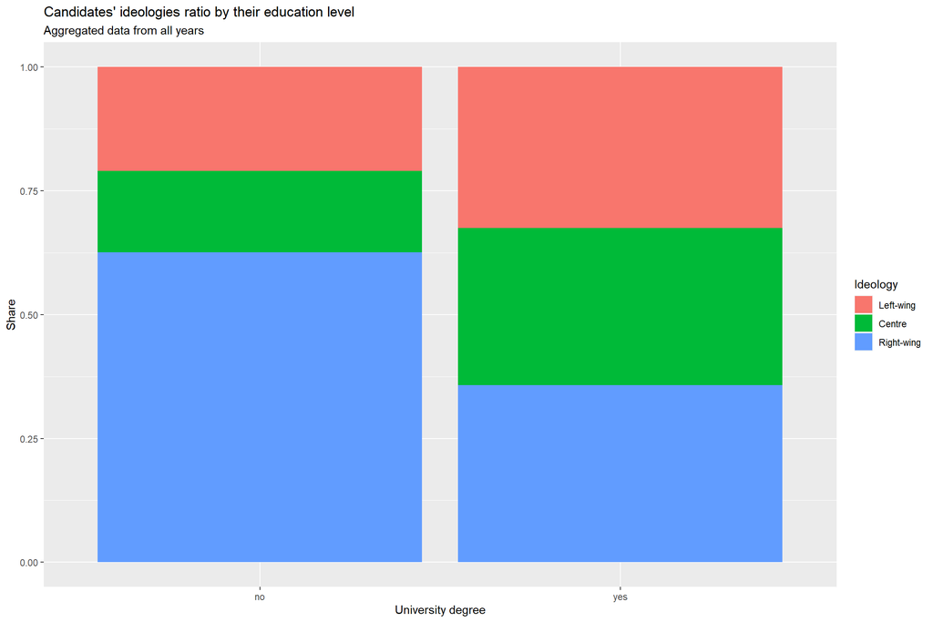

```r
snem_long %>%
  mutate(ideology = fct_relevel(ideology, "Levice", "Střed", "Pravice")) %>%
    ggplot(aes(degree)) +
        geom_bar(aes(fill = ideology), position = "fill") +
        scale_fill_discrete(name = "Ideology", labels = c("Left-wing", "Centre", "Right-wing")) +
        labs(title = "Candidates' ideologies ratio by their education level",
             subtitle = "Aggregated data from all years",
             x = "University degree",
             y = "Share")
```

### Modelling

In the last part different classification models will be trained and compared. Before that the data will be prepared accordingly – unimportant variables will be removed.

```r
library(caret) # caret package will be used for ML

snem_ml <- snem_long %>%
        select(-name, -year)

head(snem_ml)
```

|  | age | degree | field | sex | region | ideology | mandate |
| --- | --- | --- | --- | --- | --- | --- | --- |
| 1 | 45 | no | management | M | Moravskoslezský kraj | Střed | no |
| 2 | 63 | yes | státní zaměstnanec | M | Moravskoslezský kraj | Střed | no |
| 3 | 51 | yes | zdravotnictví | M | Moravskoslezský kraj | Střed | no |
| 4 | 51 | yes | státní zaměstnanec | F | Moravskoslezský kraj | Střed | no |
| 5 | 60 | yes | podnikání | M | Moravskoslezský kraj | Střed | no |
| 6 | 33 | yes | státní zaměstnanec | F | Moravskoslezský kraj | Střed | no |

Original dataset is highly unbalanced:

```r
table(snem_ml$mandate)
```

```
##
##   yes    no
##  1000 27767
```

The combination of down- and upsampling will be used to achieve class’ balance

```r
library(ROSE)

snemRose <- ROSE(mandate ~ ., data = snem_ml)$data %>%
  # since age cannot have non-integer value, all values will be rounded down
  mutate(age = floor(age),
         mandate = factor(mandate, levels = c("yes", "no")))

table(snemRose$mandate)
```

```
##
##   yes    no
## 14444 14323
```

The last preprocessing step is categorical variable dummifying

```r
library(fastDummies) # library for variable dummifying

snemDummified <- dummy_cols(snemRose, select_columns = c("degree", "sex", "field", "region", "ideology"),
                            remove_selected_columns = TRUE)

head(snemDummified)
```

|  | age | mandate | degree_no | degree_yes | sex_F | sex_M | field_důchodce | field_finance | field_jine | field_management | field_nezaměstnaný | field_odborný pracovník | field_podnikání | field_politika | field_právo | field_řemeslo | field_soukromý sektor | field_sportovec | field_státní zaměstnanec | field_student | field_umění | field_věda | field_zdravotnictví | field_zemědělství | field_živnost | region_Hlavní město Praha | region_Jihočeský kraj | region_Jihomoravský kraj | region_Karlovarský kraj | … |
| --- | --- | --- | --- | --- | --- | --- | --- | --- | --- | --- | --- | --- | --- | --- | --- | --- | --- | --- | --- | --- | --- | --- | --- | --- | --- | --- | --- | --- | --- | --- |
| 1 | 49 | no | 1 | 0 | 0 | 1 | 0 | 0 | 0 | 0 | 0 | 0 | 0 | 0 | 0 | 0 | 0 | 0 | 0 | 0 | 0 | 0 | 0 | 0 | 1 | 0 | 0 | 0 | 0 | … |
| 2 | 55 | no | 1 | 0 | 1 | 0 | 0 | 1 | 0 | 0 | 0 | 0 | 0 | 0 | 0 | 0 | 0 | 0 | 0 | 0 | 0 | 0 | 0 | 0 | 0 | 0 | 0 | 0 | 0 | … |
| 3 | 69 | no | 0 | 1 | 0 | 1 | 1 | 0 | 0 | 0 | 0 | 0 | 0 | 0 | 0 | 0 | 0 | 0 | 0 | 0 | 0 | 0 | 0 | 0 | 0 | 0 | 0 | 0 | 0 | … |
| 4 | 40 | no | 0 | 1 | 0 | 1 | 0 | 0 | 0 | 0 | 0 | 0 | 0 | 1 | 0 | 0 | 0 | 0 | 0 | 0 | 0 | 0 | 0 | 0 | 0 | 0 | 0 | 0 | 0 | … |
| 5 | 22 | no | 1 | 0 | 0 | 1 | 0 | 0 | 0 | 0 | 0 | 0 | 0 | 0 | 0 | 0 | 1 | 0 | 0 | 0 | 0 | 0 | 0 | 0 | 0 | 0 | 0 | 0 | 0 | … |
| 6 | 53 | no | 1 | 0 | 1 | 0 | 0 | 0 | 0 | 0 | 0 | 0 | 0 | 0 | 0 | 0 | 1 | 0 | 0 | 0 | 0 | 0 | 0 | 0 | 0 | 1 | 0 | 0 | 0 | … |

The dataset will be divided into train and test by 3:1 ratio

```r
# train and test data partition
trainIndex <- createDataPartition(snemDummified$mandate, p = 0.75,
                                  list = FALSE, times = 1)

snemTrain <- snemDummified[trainIndex, ]
snemTest <- snemDummified[-trainIndex, ]

nrow(snemTrain)
```

```
## [1] 21576
```

```r
nrow(snemTest)
```

```
## [1] 7191
```

5 way cross validation will be used during training process for all models. Following three algorithms are to be compared: Logistic Regression, Random Forest and Support Vector Classifier. Since the task is binary classification, ROC metric will be used to pick the best model during the grid search process.

Logistic regression does not have any hyperparameters to tune, so that no grid search will be performed.

```r
# 5-way Cross Validation initialisation
ctrl <- trainControl(method = "cv",
                     number = 5,
                     classProbs = TRUE,
                     summaryFunction = twoClassSummary)

# Logistic Regression model fitting
glmModel <- train(
  mandate ~ ., data = snemTrain,
  method = "glm",
  trControl = ctrl,
  metric = "ROC",
  # normalising and principal component analysis are applied as preprocess steps
  preProcess = c("center", "scale", "pca")
)

glmModel
```

```
## Generalized Linear Model
##
## 21576 samples
##    41 predictor
##     2 classes: 'yes', 'no'
##
## Pre-processing: centered (41), scaled (41), principal component
##  signal extraction (41)
## Resampling: Cross-Validated (5 fold)
## Summary of sample sizes: 17261, 17260, 17260, 17262, 17261
## Resampling results:
##
##   ROC       Sens       Spec
##   0.818233  0.7969174  0.6922646
```

The random forest model has three hyperparameters:

- **mtry**, which is randomly selected predictors, in our case the maximum value is 6 – number of original features
- **splitrule** – method for trees splitting, in this grid only standard “gini” rule is used
- **min.node.size** – minimal node size, which is basically the depth of a tree

```r
library(ranger)

# initialising the hyperparameter grid
randfGrid <- expand.grid(mtry = c(4, 6),
                         splitrule = "gini",
                         min.node.size = seq(1, 6, 3))

# Random Forest model fitting
randfModel <- train(
  mandate ~ ., data = snemTrain,
  method = "ranger",
  trControl = ctrl,
  tuneGrid = randfGrid,
  metric = "ROC",
  preProcess = c("center", "scale", "pca")
)

randfModel
```

```
## Random Forest
##
## 21576 samples
##    41 predictor
##     2 classes: 'yes', 'no'
##
## Pre-processing: centered (41), scaled (41), principal component
##  signal extraction (41)
## Resampling: Cross-Validated (5 fold)
## Summary of sample sizes: 17260, 17260, 17262, 17262, 17260
## Resampling results across tuning parameters:
##
##   mtry  min.node.size  ROC        Sens       Spec
##   4     1              0.9420447  0.9265209  0.8605601
##   4     4              0.9432398  0.9280902  0.8607459
##   6     1              0.9422875  0.9263364  0.8600016
##   6     4              0.9431774  0.9289209  0.8599083
##
## Tuning parameter 'splitrule' was held constant at a value of gini
## ROC was used to select the optimal model using the largest value.
## The final values used for the model were mtry = 4, splitrule = gini
##  and min.node.size = 4.
```

The SVC model has only one hyperparameter – **cost**. It stands for regularisation power, in our case it will be either 0.1 or 1.

```r
library(e1071)

svcGrid <- expand.grid(cost = c(0.1, 1))

svcModel <- train(
  mandate ~ ., data = snemTrain,
  method = "svmLinear2",
  trControl = ctrl,
  tuneGrid = svcGrid,
  metric = "ROC",
  preProcess = c("center", "scale", "pca")
)

svcModel
```

```
## Support Vector Machines with Linear Kernel
##
## 21576 samples
##    41 predictor
##     2 classes: 'yes', 'no'
##
## Pre-processing: centered (41), scaled (41), principal component
##  signal extraction (41)
## Resampling: Cross-Validated (5 fold)
## Summary of sample sizes: 17261, 17261, 17261, 17261, 17260
## Resampling results across tuning parameters:
##
##   cost  ROC        Sens       Spec
##   0.1   0.8109255  0.8058722  0.6439536
##   1.0   0.8107659  0.8075336  0.6431161
##
## ROC was used to select the optimal model using the largest value.
## The final value used for the model was cost = 0.1.
```

```r
resamps <- resamples(list(GLM = glmModel,
                          RandF = randfModel,
                          SVC = svcModel))

summary(resamps)
```

```
##
## Call:
## summary.resamples(object = resamps)
##
## Models: GLM, RandF, SVC
## Number of resamples: 5
##
## ROC
##            Min.   1st Qu.    Median      Mean   3rd Qu.      Max. NA's
## GLM   0.8091871 0.8152937 0.8194644 0.8182330 0.8197977 0.8274221    0
## RandF 0.9394833 0.9420507 0.9433348 0.9432398 0.9452721 0.9460580    0
## SVC   0.7994002 0.8073713 0.8081951 0.8109255 0.8149473 0.8247137    0
##
## Sens
##            Min.   1st Qu.    Median      Mean   3rd Qu.      Max. NA's
## GLM   0.7692663 0.7940905 0.8060942 0.7969174 0.8061837 0.8089525    0
## RandF 0.9206276 0.9256694 0.9270881 0.9280902 0.9312096 0.9358560    0
## SVC   0.7941855 0.8024919 0.8075681 0.8058722 0.8120960 0.8130194    0
##
## Spec
##            Min.   1st Qu.    Median      Mean   3rd Qu.      Max. NA's
## GLM   0.6872964 0.6913408 0.6913408 0.6922646 0.6956724 0.6956724    0
## RandF 0.8528864 0.8576082 0.8621974 0.8607459 0.8641228 0.8669148    0
## SVC   0.6165658 0.6305258 0.6387337 0.6439536 0.6424581 0.6914844    0
```

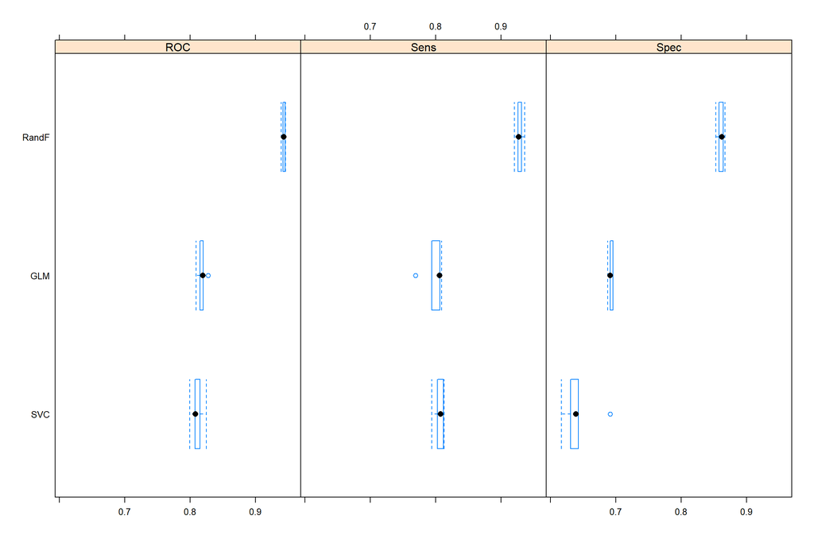

```r
bwplot(resamps, layout = c(3, 1))
```

Now the models will be assessed on testing data set.

```r
# this function will be used to create class probabilities
predAndProb <- function(origDf, model){
  # binding the testing set with the predicted probabilities
  modDf <- cbind(origDf, predict(model, newdata = origDf, type = "prob") %>%
    # predicted class will be chosen based on biggest probability
                            mutate("pred" = as.factor(names(.)[apply(., 1, which.max)]))) %>%
    mutate(pred = factor(pred, levels = c("yes", "no")))

  return(modDf)
}

snemGml <- predAndProb(snemTest, glmModel)
snemRandf <- predAndProb(snemTest, randfModel)
snemSvc <- predAndProb(snemTest, svcModel)
```

Confusion matrix shows the performance of an algorithm, with right predictions being on the main diagonal and wrong predictions on counter diagonal, so that $True Positives$ and $True Negatives$ are on the former, $False Positives$ and $False Negatives$ are on the latter.

Following metrics were chosen for models assessing:

- **Precision**: $\frac{TP}{TP + FP}$ – how precisely model assigns positive class
- **Sensitivity (Recall)**: $\frac{TP}{TP + FN}$ – how well a model can identify true positives
- **Specificity**: $\frac{TN}{TN + FP}$ – how well a model can identify true negatives
- **ROC AUC**: area under the ROC curve ($TP$ rate against the $FP$ rate)

The logistic regression defines the right class most times, although it often classifies negative class as positive ($FP$, upper right corner), which resembles in lower precision rate.

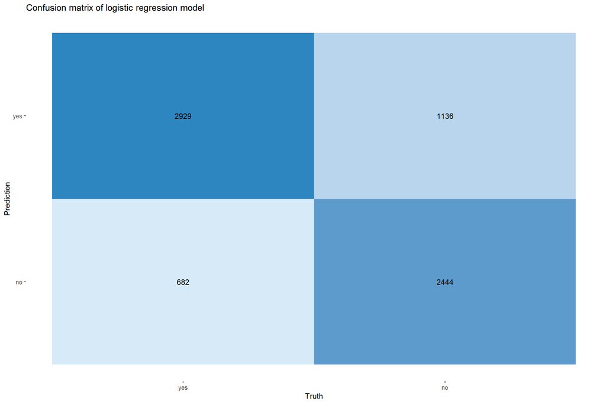

```r
library(yardstick)

conf_mat(snemGml, mandate, pred) %>%
    autoplot(type = "heatmap") +
        labs(title = "Confusion matrix of logistic regression model") +
        scale_fill_gradient(low="#D6EAF8", high = "#2E86C1")
```

The confusion matrix above confirms the metrics below:

```r
# yardstick's metric_Set will be used for models' assessment
classMetrics <- metric_set(precision, sensitivity, specificity, roc_auc)

classMetrics(snemGml, truth = mandate, estimate = pred, yes)
```

| .metric | .estimator | .estimate |
| --- | --- | --- |
| precision | binary | 0.7205412 |
| sensitivity | binary | 0.8111327 |
| specificity | binary | 0.6826816 |
| roc_auc | binary | 0.8137778 |

Random forest’s matrix on the other side looks much better. The model performs fairly well, the counter diagonal holds smaller numbers this time. This algorithm has the best metrics on testing data out of all others.

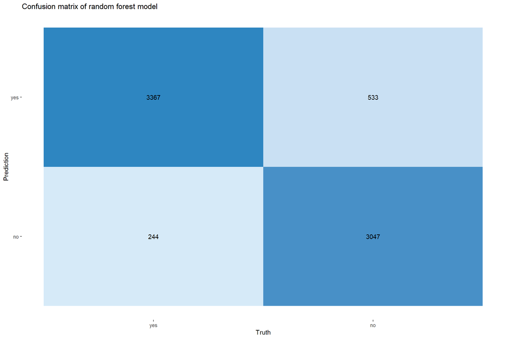

```r
conf_mat(snemRandf, mandate, pred) %>%
  autoplot(type = "heatmap") +
  labs(title = "Confusion matrix of random forest model") +
  scale_fill_gradient(low="#D6EAF8", high = "#2E86C1")
```

```r
classMetrics(snemRandf, truth = mandate, estimate = pred, yes)
```

| .metric | .estimator | .estimate |
| --- | --- | --- |
| precision | binary | 0.8633333 |
| sensitivity | binary | 0.9324287 |
| specificity | binary | 0.8511173 |
| roc_auc | binary | 0.9417386 |

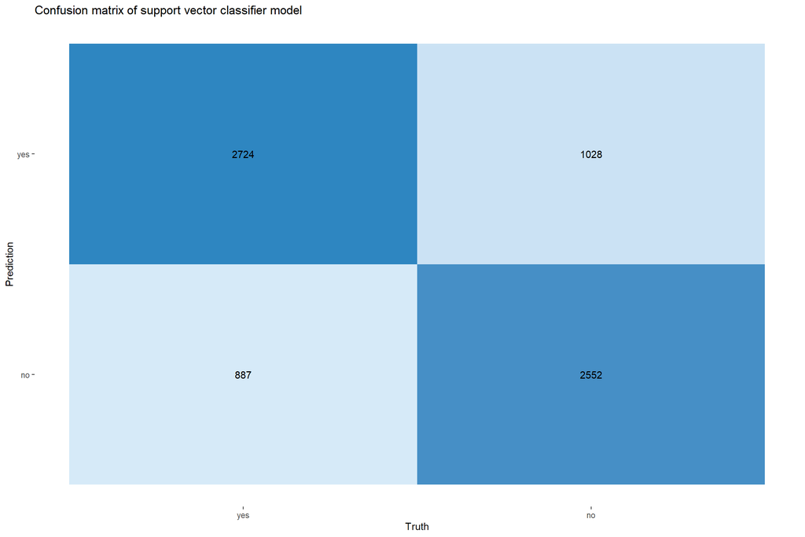

```r
conf_mat(snemSvc, mandate, pred) %>%
  autoplot(type = "heatmap") +
  labs(title = "Confusion matrix of support vector classifier model") +
  scale_fill_gradient(low="#D6EAF8", high = "#2E86C1")
```

```r
classMetrics(snemSvc, truth = mandate, estimate = pred, yes)
```

| .metric | .estimator | .estimate |
| --- | --- | --- |
| precision | binary | 0.7260128 |
| sensitivity | binary | 0.7543617 |
| specificity | binary | 0.7128492 |
| roc_auc | binary | 0.8065161 |

### Conclusion

In this report following results have been discovered:

Three models were compared during the modelling process: logistic regression, random forest and support vector classifier. The best one of them was random forest algorithm with ROC AUC around 0.94.